```python
import logging
import pomocni
from generator import pomocni as gen
from konstante import postavke, imena
from generator.nasumicni import NasumicniGradovi
from generator.kruzni import GradoviNaKruznici
from algoritmi import pomocni as algos
from vizualizacija import plot

pomocni.set_logger(False)
pomocni.ispis_verzija_koristenih_modula()
pomocni.init_putanje()
logging.getLogger().setLevel(logging.CRITICAL)
```

```
Korištene verzije modula su:
Python verzija: 3.5.5
Numpy verzija: 1.14.5
Pandas verzija: 0.23.4
Matplotlib verzija: 2.2.2
Seaborn verzija: 0.9.0
```

# Genetski algoritam za određivanje optimalnog rješenja za probelm trgovačkog putnika

## Definiranje problema

Problem trgovačkog putnika se definira kao: Za listu gradova i udaljenostima između njih, koji je najkraći put za obići sve gradove i vratiti se u početni grad?

Detaljnije definiranje problema:

- Gradovi su smješteni na 2D kartu, svaki grad ima koordinate (x, y);
- svaki grad se mora posjetiti samo jednom;
- udaljenost između gradova se smatra euklidska udaljenost između dvije točke na 2D plohi definirana kao $$d_{ab} = \sqrt{(x_a-x_b)^2 + (y_a-y_b)^2},$$ gdje $d_{ab}$ označava udaljenost između gradova a i b s koordinatama x i y.

Za manji broj gradova je moguće ispitati sve moguće kombinacije redoslijeda posjećivanja gradova. Za veći broj gradova to nije moguće jer je broj kombinacija N! gdje N označava broj gradova, kao što je prikazano sljedećom slikom.

```python
nasumicni_args = gen.get_args_nasumicnih_gradova(postavke.MANJI_BROJ_GRADOVA)
nasumicni_evaulatori = gen.generiranje_gradova(NasumicniGradovi, nasumicni_args)
algos.ispitivanje_bf_algoritma(
    nasumicni_evaulatori,
    postavke.BROJ_ITERACIJA,
    imena.BF_FILE_VAR_BR_GRADOVA
)
```

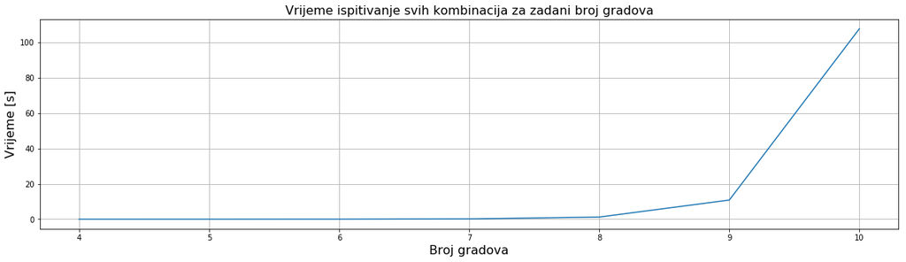

```python
plot.prikaz_bf_vs_br_gradova(imena.PUTANJA_REZULTATA, imena.BF_FILE_VAR_BR_GRADOVA)
```

Stoga za rješavanje ovog problema koristit će se genetski algoritam.

## Genetski algoritam

Temeljna računalna ideja iza algoritama poput genetskog algoritma (GA) je ispitivanje više mogućih rješenja te pomoću heuristike odrediti dobre karakteristike koje će se naslijediti na iduću iteraciju algoritma.

U GA to je postignuto tako da se generira veći broj jedinki, gdje svaka jedinka ima sekvencu gena. Za svaku jedinku u generaciji se računa fitnes te pomoću fitnesa se određuje koje jedinke će preći u sljedeću generaciju. Kako bi se istražili različite varijante gena uvodi se vjerojatnost mutiranja koja nasumično jedinkama izmijeni redoslijed dva gena. Uz navedeno, između dvije generacije se također uvodi i križanje jedinki gdje se na određenom dijelu populacije usvoji jedan dio gena jedne jedinke i dio gena druge jedinke. Križanje je kontrolirano pomoću parametra vjerojatnosti križanja.

Dani opis algoritma je općeniti GA, u ovom problemu geni se smatraju gradovi, a određena sekvenca gena je put kojim će se obići gradovi. Fitnes je definiran kao inverz duljine obilaska.

## Način evaluacije

Algoritam će se provjeravati na osnovu dvije metrike. Prva je vrijeme izvođenja algoritma, dok je druga točnost dobivenog rješenja.

Kako bi se dobio što bolji uvid u odnose između navedenih metrika i parametara GA (broj jedinki/veličina populacije, vjerojatnosti mutiranja i vjerojatnosti križanja), izvršit će se više ispitivanja algoritma s različitim parametrima i različitim veličinama problema.

## Ispitivanje vremena izvršavanja

Za manji broj gradova, vrijeme će se usporediti s vremenom potrebnim za ispitivanjem svih kombinacija. Za veći broj gradova prikazat će se samo vrijeme izvođenja GA.

## Ispitivanje točnosti

Za manji broj gradova, generira će se nasumični gradovi te će se ispitati sve kombinacije obilaska i uzet će se obilazak koji ima najmanju duljinu. Na slici ispod je prikazano kako izgledaju generirane koordinate gradove kao i matrica udaljenosti. Matrica udaljenosti je skup udaljenosti između gradova gdje $d_{ij}=d_{ji}$ označava udaljenost između $i$-tog i $j$-tog grada.

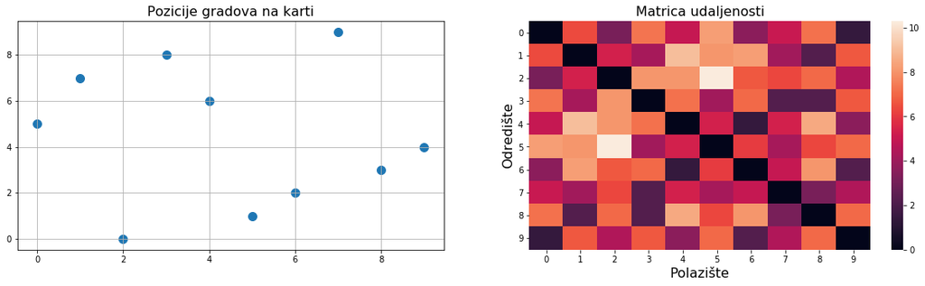

```python
plot.prikaz_gradova(NasumicniGradovi(10))
```

Za veći broj gradova, gradovi će se generirati na kružnici radijusa 1 te kut između svih gradova će biti jednak. Takav način generiranja gradova omogućuje jednostavno pronalaženje duljinu najkraćeg obilaska. Najkraći obilazak je pratiti kružnicu. Prikaz generiranja gradova na kružnici i pripadajuće matrice udaljenosti je prikazano sljedećom slikom.

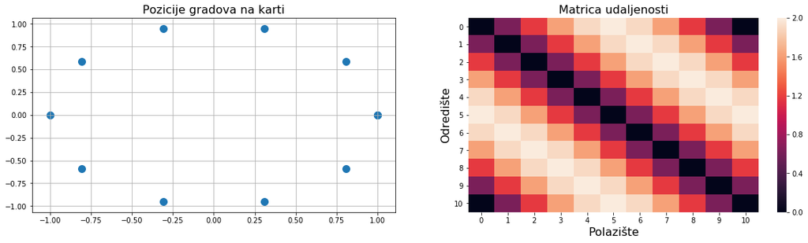

```python
plot.prikaz_gradova(GradoviNaKruznici(10))
```

Kako bi se dobila što vjerodostojnija slika rezultata, svako ispitivanje će se izvršiti 5 puta i uzet će se medijan dobivenih rezultata.

## Odabir parametara algoritma

Odabiru parametara će se pristupiti na sljedeći način:

1. Za konstantnu veličinu populacije i konstantan broj gradova, ispitat će se različite kombinacije vjerojatnosti mutacije i vjerojatnosti križanja.
2. Za konstantan broj gradova, vjerojatnost mutiranja i vjerojatnost križanja, ispitat će se različite veličine populacije

### 1. Odabir vjerojatnosti mutiranja i križanja

Broj jedinki je 1000, broj gradova je 15, a vjerojatnosti križanja i mutiranja će varirati između 0 i 1 s korakom 0.1. Uvjet zaustavljanja algoritma je postavljen tako da ako se u 100 generacija ne promijeni najkraći put algoritam se zaustavlja.

Broj jedinki i broj gradova je odabran iz razloga jer postoji veliki broj kombinacija i dovoljan broj uzoraka za određivanje vjerojatnosti.

```python
postavka_nasumicnog_evaluatora = gen.get_args_nasumicnih_gradova(
    postavke.KONSTANTAN_BROJ_GRADOVA
)
nasumicni_evaulatori = gen.generiranje_gradova(
    NasumicniGradovi, postavka_nasumicnog_evaluatora
)

algos.ispitivanje_ga_algoritma(
    nasumicni_evaulatori,
    postavke.BROJ_ITERACIJA,
    postavke.KONSTANTAN_BROJ_JEDINKI,
    postavke.VARIJACIJA_VJV_MUTACIJE,
    postavke.VARIJACIJA_VJV_KRIZANJA,
    imena.GA_FILE_VAR_VJV
)
```

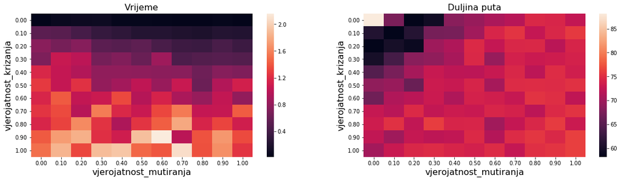

```python
plot.prikaz_varijacija(imena.PUTANJA_REZULTATA, imena.GA_FILE_VAR_VJV)
```

Iz rezultata je vidljivo kako ako je vjerojatnost križanja postavljeno na 0, algoritam radi jako brzo što može biti iz dva razloga. Prvi razlog je taj da se ne ispituju priviše kombinacija i brzo se dolazi u lokalni minimum, drugi razlog je kompleksnost izvođenja križanja jer implementira više vremenski zahtjevnih operacija.

S druge strane, svrha vjerojatnosti mutiranja nije pretežito očita, može se zaključiti da ne utječe previše na vremensku složenost, ali male razine vjerojatnosti pomažu u pronalasku optimalnog rješenja.

Nakon varijacije vjerojatnosti odabrane su vrijednosti 0.1 za vjerojatnost mutiranja i 0.2 za vjerojatnost križanja.

### 2. Odabir broja jedinki (veličine populacije)

Kako je prije pokazano, ako su vjerojatnost mutiranja i vjerojatnost križanja postavljeni na 0, tada je moguće vidjeti koliko je vremena potrebno iz izvršavanje 100 generacija. Time se može dobiti uvid kako djeluje broj jedinki na vrijem izvršavanje algoritma.

```python
postavka_nasumicnog_evaluatora = gen.get_args_nasumicnih_gradova(
    postavke.KONSTANTAN_BROJ_GRADOVA, ucitavanje=True
)
nasumicni_evaulatori = gen.generiranje_gradova(
    NasumicniGradovi, postavka_nasumicnog_evaluatora
)

algos.ispitivanje_ga_algoritma(
    nasumicni_evaulatori,
    postavke.BROJ_ITERACIJA,
    postavke.VARIJACIJA_BROJA_JEDINKI,
    postavke.VJEROJATNOSTI_MUTACIJE_0,
    postavke.VJEROJATNOSIT_KRIZANJA_0,
    imena.GA_FILE_VAR_POP_VJV_0
)
```

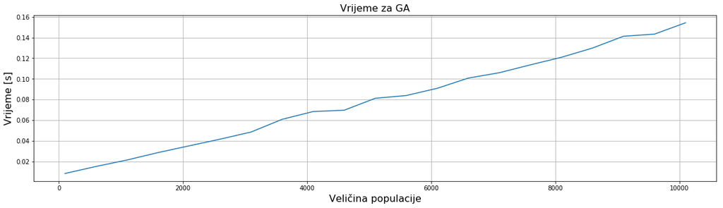

```python
plot.prikaz_ga_vs_br_jedinki(imena.PUTANJA_REZULTATA, imena.GA_FILE_VAR_POP_VJV_0)
```

Može se primjetiti kako vijeme potrebno za izvršavanje raste linearno s obzirom na veličinu populacije. Prikazani rezultati ne uključuju dijelove algoritma koji su zaduženi za mutiranje i križanje. Stoga sljedeća slika prikazuje stvarne uvijete pod kojim algoritam radi. Vjerojatnost križanja će se postaviti na 0.2, a vjerojatnost mutiranja na 0.1. Broj gradova je i dalje 15.

```python
postavka_nasumicnog_evaluatora = gen.get_args_nasumicnih_gradova(
    postavke.KONSTANTAN_BROJ_GRADOVA, ucitavanje=True
)
nasumicni_evaulatori = gen.generiranje_gradova(
    NasumicniGradovi, postavka_nasumicnog_evaluatora
)

algos.ispitivanje_ga_algoritma(
    nasumicni_evaulatori,
    postavke.BROJ_ITERACIJA,
    postavke.VARIJACIJA_BROJA_JEDINKI,
    postavke.VJEROJATNOSTI_MUTACIJE,
    postavke.VJEROJATNOSIT_KRIZANJA,
    imena.GA_FILE_VAR_POP
)
```

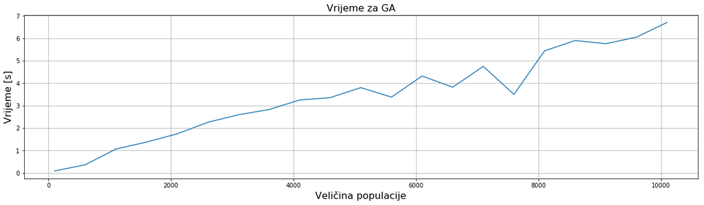

```python
plot.prikaz_ga_vs_br_jedinki(imena.PUTANJA_REZULTATA, imena.GA_FILE_VAR_POP)
```

Vidljivo je kako algoritam i dalje slijedi linearnu ovisnost u odnosu na veličinu populacije.

## Rezultati

Kako je ranije opisano, analiza će se razdvojiti na dva dijela. Prvi dio će se izvršiti s nasumično generiranim gradovima veličine od 4 do 10. Algoritam će biti podešen s vjerojatnosti križanja 0.2, vjerojatnosti mutiranja 0.1 i 100 jedinki. GA rezultati će se usporediti s rezultatima ispitivanja svih kombinacija. Također, prikazat će se i potrebno vrijeme za oba izvođenje oba algoritma.

Drugi dio će se provesti s gradovima generiranim na kružnici, broj gradova će varirati između 12 i 92 s korakom od 10. Algoritam će biti podešen s vjerojatnosti križanja 0.2, vjerojatnosti mutiranja 0.1 i 1000, 3000 i 5000 jedinki. Vrijeme će se u ovom slučaju prikazati samo za GA.

Duljina puta će biti prikazana kao postotak odstupanja GA i najkraćeg puta. Vrijeme će biti u sekundama.

```python
# Manji broj gradova (nasumicno) ##
nasumicni_args = gen.get_args_nasumicnih_gradova(postavke.MANJI_BROJ_GRADOVA, ucitavanje=True)
nasumicni_evaulatori = gen.generiranje_gradova(NasumicniGradovi, nasumicni_args)

algos.ispitivanje_ga_algoritma(
    nasumicni_evaulatori,
    postavke.BROJ_ITERACIJA,
    postavke.MANJI_BROJ_JEDINKI,
    postavke.VJEROJATNOSTI_MUTACIJE,
    postavke.VJEROJATNOSIT_KRIZANJA,
    imena.GA_FILE_MANJI_BR_GRADOVA
)
```

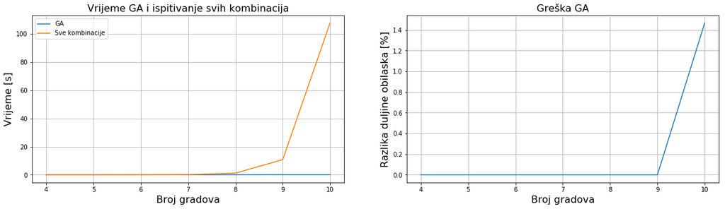

```python
plot.prikaz_ga_vs_ref(
    imena.PUTANJA_REZULTATA,
    imena.BF_FILE_VAR_BR_GRADOVA,
    imena.GA_FILE_MANJI_BR_GRADOVA
)
```

```python
## Veci broj gradova ##
kruzni_args = gen.get_args_kruznih_gradova(postavke.VECI_BROJ_GRADOVA)
kruzni_evaulatori = gen.generiranje_gradova(GradoviNaKruznici, kruzni_args)

algos.ispitivanje_kruznih_gradova(kruzni_evaulatori, imena.REF_FILE_VAR_BR_GRADOVA_VECI)
algos.ispitivanje_ga_algoritma(
    kruzni_evaulatori,
    postavke.BROJ_ITERACIJA,
    postavke.VECI_BROJ_JEDINKI,
    postavke.VJEROJATNOSTI_MUTACIJE,
    postavke.VJEROJATNOSIT_KRIZANJA,
    imena.GA_FILE_VECI_BR_GRADOVA
)
```

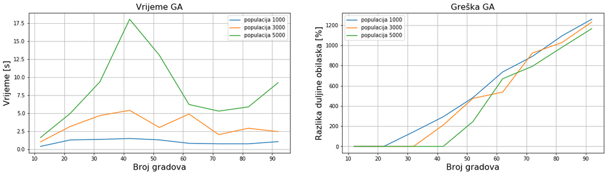

```python
plot.prikaz_ga_vs_ref(
    imena.PUTANJA_REZULTATA,
    imena.REF_FILE_VAR_BR_GRADOVA_VECI,
    imena.GA_FILE_VECI_BR_GRADOVA
)
```

Zanimljivo je vidjeti kako vrijeme potrebno za pronalazak rješenja s 5000 jedinki raste do 42 grada te potom počne opadati. Jedno od objašnjenja bi bilo da je algoritam ušao u lokalni minimum te za izaći bi trebalo imati ili više jedinkij ili možda neke druge vrijednosti vjerojatnosti križanja i/ili mutiranja.